# A (very) short introduction to R and RStudio

## Practice time 1: “Playing R’s lottery”

## Data Structures

## Data Structures

- We usually associate the concept of data structure to a table with several rows and columns

| id | sex | t0_date | t0_beh_prob | intervention | t1_date | t1_beh_prob |
| --- | --- | --- | --- | --- | --- | --- |
| 1 | Male | 2017-11-02 | 11 | TRUE | 2018-11-01 | 8 |
| 2 | Male | 2017-11-04 | 14 | TRUE | 2018-11-03 | 11 |
| 3 | Female | 2017-11-05 | 5 | FALSE | 2018-11-04 | 7 |
| 4 | Male | 2017-11-10 | 20 | TRUE | 2018-11-10 | 15 |
| 5 | Female | 2017-11-11 | 16 | FALSE | 2018-11-11 | 16 |

*rows represent observations and columns the variables*

## Data Structures

### R has 5 general types of data structures:

- **Vectors**
- **Matrices**
- Array (multidimensional matrices)
- **Data-frames**
- List (can contain de vectors, matrices, data-frames, and lists..)

*These structures differ in the type of data they can store, complexity, how they are created, and way of indexing*

## Data classes

R can manage different types or classes of data:  
- Numeric data (integer or decimal)  
- Logical data (True or False)  
- Character data (strings)

```r
a <- "one" # Creates a character vector
b <- 1 # Creates a numeric vector
c <- 1L # Creates a numeric (integer) vector
d <- TRUE # Creates a logical vector

# Prints objects and their classes
print(c(a, class(a)))
print(c(b, class(b)))
print(c(c, class(c)))
print(c(d, class(d)))
```

*some data structures (vectors and matrices) can only hold a single type of data, while others (data-frames and lists) can store different types*

## Data Structures - Vectors

- One-dimensional arrays that can hold **numeric**, **character**, or **logical** data
- Use the combine or concatenate function, **c()**, to create vectors

```r
id <- c(1.2, 3.1, 2.1, 4.5) # numerical vector
id
```

```
## [1] 1.2 3.1 2.1 4.5
```

```r
age <-  c(20, 24, 21, 40) # numerical vector
class(age) # returns object class
```

```
## [1] "numeric"
```

## Data Structures - Vectors (cont.)

```r
name <- c("Ana", "Manuel", "Afonso", "Maria") # character vector
name
```

```
## [1] "Ana"    "Manuel" "Afonso" "Maria"
```

```r
class(name)
```

```
## [1] "character"
```

```r
length(name) # returns object lenght
```

```
## [1] 4
```

## Data Structures - Vectors (cont.)

```r
ruser <- c(TRUE, FALSE, FALSE, TRUE) # logical vector
ruser
```

```
## [1]  TRUE FALSE FALSE  TRUE
```

```r
class(ruser)
```

```
## [1] "logical"
```

```r
table(ruser)
```

```
## ruser
## FALSE  TRUE
##     2     2
```

## Data Structures - Vectors (cont.)

- we can access the elements of a vector through their index

```r
rbaseskills <- c(40, 35, 20, 60) # previous skills in R using a scale from 1 to 100
rmotivation <- c(60, 90, 10, 50) # motivation in a scale from 1 to 100
```

- each vector’s element was its own index, allowing the identification

```r
rbaseskills[2] # returns vector's 2nd value
```

```
## [1] 35
```

```r
rbaseskills[c(2,3)] # returns vector's 2nd and 3rd values
```

```
## [1] 35 20
```

## Data Structures - Vectors (cont.)

- Basic operations with vectors

```r
rbaseskills > rmotivation # logical operation
```

```
## [1] FALSE FALSE  TRUE  TRUE
```

```r
rbaseskills + 1 # arithmetic operation
```

```
## [1] 41 36 21 61
```

```r
rbaseskills + rmotivation # arithmetic operation
```

```
## [1] 100 125  30 110
```

## Data Structures - Matrices

- Two-dimensional array **containing elements of same mode** (numeric, character, or logical)
  - similar to a vector, but with two dimensions (row, column)

```r
dailyuse <- rnorm(20, mean = 2, sd = .5) # Creates a vector with 20 elements
dailyuse <- round(dailyuse, 0) # rounds the vector to 0 decimals
dailyuse
```

```
##  [1] 2 2 2 2 2 2 2 2 2 2 1 1 2 1 2 1 2 2 2 2
```

```r
class(dailyuse)
```

```
## [1] "numeric"
```

## Data Structures - Matrices (cont.)

- We can use the **matrix()** function to create a matrix

```r
dailyuse <- matrix(dailyuse, nrow = 4, ncol = 5, dimnames = list(NULL,
                              c("day1", "day2", "day3", "day4", "day5")))
dailyuse
```

```
##      day1 day2 day3 day4 day5
## [1,]    2    2    2    2    2
## [2,]    2    2    2    1    2
## [3,]    2    2    1    2    2
## [4,]    2    2    1    1    2
```

```r
class(dailyuse)
```

```
## [1] "matrix" "array"
```

## Data Structures - Matrices (cont.)

- to access data in a matrix we need, first, to identify the row(s) and, second, the column(s) where data is located

```r
dailyuse[1, 2]  # select element in row 1, column 2
```

```
## day2
##    2
```

```r
dailyuse[c(1, 4), ] # leaving column field blank will select all columns
```

[output not shown]

```r
dailyuse[2:3, -1] # select rows from 2 to 3 and all columns except column 1
```

```
##      day2 day3 day4 day5
## [1,]    2    2    1    2
## [2,]    2    1    2    2
```

## Data Structures - Data frame

- A data frame is a special kind of matrix
  - Allows to store different types of data in different columns
  - Similar to the type of data structure used in most popular statistical packages (e.g., spss)
- Use the **data.frame()** to create a data frame

```r
df  <-  data.frame(id, name, ruser, rbaseskills, rmotivation, dailyuse)
df
```

```
##    id   name ruser rbaseskills rmotivation day1 day2 day3 day4 day5
## 1 1.2    Ana  TRUE          40          60    2    2    2    2    2
## 2 3.1 Manuel FALSE          35          90    2    2    2    1    2
## 3 2.1 Afonso FALSE          20          10    2    2    1    2    2
## 4 4.5  Maria  TRUE          60          50    2    2    1    1    2
```

## Data Structures - Data frame (cont.)

- R makes easy to import data from a variety of sources (see [R Data Import/Export manual](http://mng.bz/urwn))
- A handy way for importing data to R is through text files (e.g., “.txt” or “.csv”)

```r
bechdel <-
  read.table(
    "G:\\My Drive\\FPCEUP\\R trainning\\GitRepo\\Intro to R\\RIntro_4h\\R_intro_data\\bechdel.csv",
    header = TRUE,
    sep = ";",
    quote = "\"",
    dec = ".",
    na.strings = " ",
    stringsAsFactors = FALSE,
    colClasses =  c("numeric", "character", "factor", "factor", "numeric", "numeric", "numeric"),
    fileEncoding="UTF-8-BOM")
```

## Data Structures - Data frame (cont.)

- Instead of the generic function, **read.table()**, we can simply use the **read.csv2()** function

```r
bechdel <-
  read.csv2(
    "G:\\My Drive\\FPCEUP\\R trainning\\GitRepo\\Intro to R\\RIntro_4h\\R_intro_data\\bechdel.csv")
dim(bechdel)
```

```
## [1] 1794    7
```

```r
head(bechdel, 2)
```

```
##   movie_year movie_title bechdel_test bechdel_test_binary   budget US_profit
## 1       2013   21 & Over            2                   0 13000000  25682380
## 2       2012    Dredd 3D            5                   1 45658735  13611086
##   Int_Profit
## 1   42195766
## 2   41467257
```

## Data Structures - Data frame (cont.)

- R has also many built-in data sets
  - Use **data()** for an overview
- Lets check the mtcars data frame

*The data was extracted from the 1974 Motor Trend US magazine, and comprises fuel consumption and 10 features of automobile design and performance for 32 automobiles (1973–74 models)*

```r
data() # lists all available datasets
browseURL("http://stat.ethz.ch/R-manual/R-devel/library/datasets/html/00Index.html")
# informations about available datasets
?mtcars # diplays information about cars dataset
```

## Data Structures - Data frame (cont.)

### Loading mtcars data frame

```r
data(mtcars)  # loading a data frame
class(mtcars)
```

```
## [1] "data.frame"
```

```r
head(mtcars, 2)
```

```
##               mpg cyl disp  hp drat    wt  qsec vs am gear carb
## Mazda RX4      21   6  160 110  3.9 2.620 16.46  0  1    4    4
## Mazda RX4 Wag  21   6  160 110  3.9 2.875 17.02  0  1    4    4
```

## Data Structures - Data frame (cont.)

### We can use a matrix-like indexing to access values in the data frame

```r
mtcars # displays a dataset
head(mtcars,2)
mtcars[1:3, 1]
```

Other way to select data in a data frame is by using the dollar sign

```r
mtcars$mpg # extract column "mpg"
```

```r
mtcars[sample(1:nrow(mtcars), 2), ]
```

```
##                     mpg cyl disp  hp drat    wt  qsec vs am gear carb
## Fiat X1-9          27.3   4   79  66 4.08 1.935 18.90  1  1    4    1
## Cadillac Fleetwood 10.4   8  472 205 2.93 5.250 17.98  0  0    3    4
```

## Data Structures - Data frame (cont.)

- We can also use logical operators to select elements that respect a certain condition

```r
mtcars$hp <= 70
```

```
##  [1] FALSE FALSE FALSE FALSE FALSE FALSE FALSE  TRUE FALSE FALSE FALSE FALSE
## [13] FALSE FALSE FALSE FALSE FALSE  TRUE  TRUE  TRUE FALSE FALSE FALSE FALSE
## [25] FALSE  TRUE FALSE FALSE FALSE FALSE FALSE FALSE
```

```r
mtcars[mtcars$hp <= 70,]
```

```
##                 mpg cyl  disp hp drat    wt  qsec vs am gear carb
## Merc 240D      24.4   4 146.7 62 3.69 3.190 20.00  1  0    4    2
## Fiat 128       32.4   4  78.7 66 4.08 2.200 19.47  1  1    4    1
## Honda Civic    30.4   4  75.7 52 4.93 1.615 18.52  1  1    4    2
## Toyota Corolla 33.9   4  71.1 65 4.22 1.835 19.90  1  1    4    1
## Fiat X1-9      27.3   4  79.0 66 4.08 1.935 18.90  1  1    4    1
```

```r
mtcars[mtcars$hp <= 70 & mtcars$mpg <= 30, "qsec"]
```

```
## [1] 20.0 18.9
```

## Built-in functions for basic statistics

## Basic functions - Inspect data structure

- Lets use mtcars to apply some R basic functions

```r
class(mtcars) # reports the data format
```

```
## [1] "data.frame"
```

```r
dim(mtcars) # reports data dimensions
```

```
## [1] 32 11
```

```r
names(mtcars) # view variable names
```

```
##  [1] "mpg"  "cyl"  "disp" "hp"   "drat" "wt"   "qsec" "vs"   "am"   "gear"
## [11] "carb"
```

## Basic functions - Inspect data structure (cont.)

```r
str(mtcars) # summarizes data structure
```

```
## 'data.frame':    32 obs. of  11 variables:
##  $ mpg : num  21 21 22.8 21.4 18.7 18.1 14.3 24.4 22.8 19.2 ...
##  $ cyl : num  6 6 4 6 8 6 8 4 4 6 ...
##  $ disp: num  160 160 108 258 360 ...
##  $ hp  : num  110 110 93 110 175 105 245 62 95 123 ...
##  $ drat: num  3.9 3.9 3.85 3.08 3.15 2.76 3.21 3.69 3.92 3.92 ...
##  $ wt  : num  2.62 2.88 2.32 3.21 3.44 ...
##  $ qsec: num  16.5 17 18.6 19.4 17 ...
##  $ vs  : num  0 0 1 1 0 1 0 1 1 1 ...
##  $ am  : num  1 1 1 0 0 0 0 0 0 0 ...
##  $ gear: num  4 4 4 3 3 3 3 4 4 4 ...
##  $ carb: num  4 4 1 1 2 1 4 2 2 4 ...
```

## Basic functions - View data

```r
head(mtcars) # returns first observations
```

```
##                    mpg cyl disp  hp drat    wt  qsec vs am gear carb
## Mazda RX4         21.0   6  160 110 3.90 2.620 16.46  0  1    4    4
## Mazda RX4 Wag     21.0   6  160 110 3.90 2.875 17.02  0  1    4    4
## Datsun 710        22.8   4  108  93 3.85 2.320 18.61  1  1    4    1
## Hornet 4 Drive    21.4   6  258 110 3.08 3.215 19.44  1  0    3    1
## Hornet Sportabout 18.7   8  360 175 3.15 3.440 17.02  0  0    3    2
## Valiant           18.1   6  225 105 2.76 3.460 20.22  1  0    3    1
```

## Basic functions - Summarize data

```r
summary(mtcars[,1:8]) # summarize R objects
```

```
##       mpg             cyl             disp             hp
##  Min.   :10.40   Min.   :4.000   Min.   : 71.1   Min.   : 52.0
##  1st Qu.:15.43   1st Qu.:4.000   1st Qu.:120.8   1st Qu.: 96.5
##  Median :19.20   Median :6.000   Median :196.3   Median :123.0
##  Mean   :20.09   Mean   :6.188   Mean   :230.7   Mean   :146.7
##  3rd Qu.:22.80   3rd Qu.:8.000   3rd Qu.:326.0   3rd Qu.:180.0
##  Max.   :33.90   Max.   :8.000   Max.   :472.0   Max.   :335.0
##       drat             wt             qsec             vs
##  Min.   :2.760   Min.   :1.513   Min.   :14.50   Min.   :0.0000
##  1st Qu.:3.080   1st Qu.:2.581   1st Qu.:16.89   1st Qu.:0.0000
##  Median :3.695   Median :3.325   Median :17.71   Median :0.0000
##  Mean   :3.597   Mean   :3.217   Mean   :17.85   Mean   :0.4375
##  3rd Qu.:3.920   3rd Qu.:3.610   3rd Qu.:18.90   3rd Qu.:1.0000
##  Max.   :4.930   Max.   :5.424   Max.   :22.90   Max.   :1.0000
```

## Basic functions - Ordering data

```r
which.max(mtcars$qsec) # Prints the row name (index) with the highest value for qsec
which.min(mtcars$qsec) # Prints the row name (index) with the lowest value for qsec
```

```r
mtcars[which.min(mtcars$qsec),]
```

```
##                 mpg cyl disp  hp drat   wt qsec vs am gear carb
## Ford Pantera L 15.8   8  351 264 4.22 3.17 14.5  0  1    5    4
```

```r
order(mtcars$qsec) # Orders the vector of indexes into ascending or descending order
```

```r
head(mtcars[order(mtcars$qsec), ], 2) # Orders the original DF using ordered indexes
```

```
##                 mpg cyl disp  hp drat   wt qsec vs am gear carb
## Ford Pantera L 15.8   8  351 264 4.22 3.17 14.5  0  1    5    4
## Maserati Bora  15.0   8  301 335 3.54 3.57 14.6  0  1    5    8
```

## Basic functions - Visualising data (cont.)

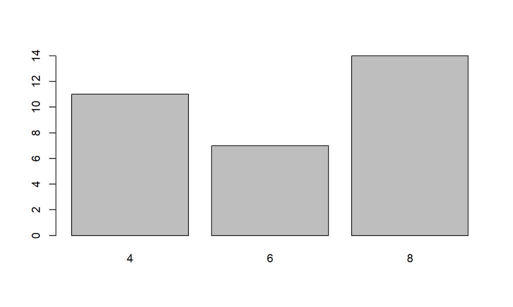

```r
barplot(table(mtcars$cyl)) # bar plot for cylinder
```

## Basic functions - Visualising data (cont.)

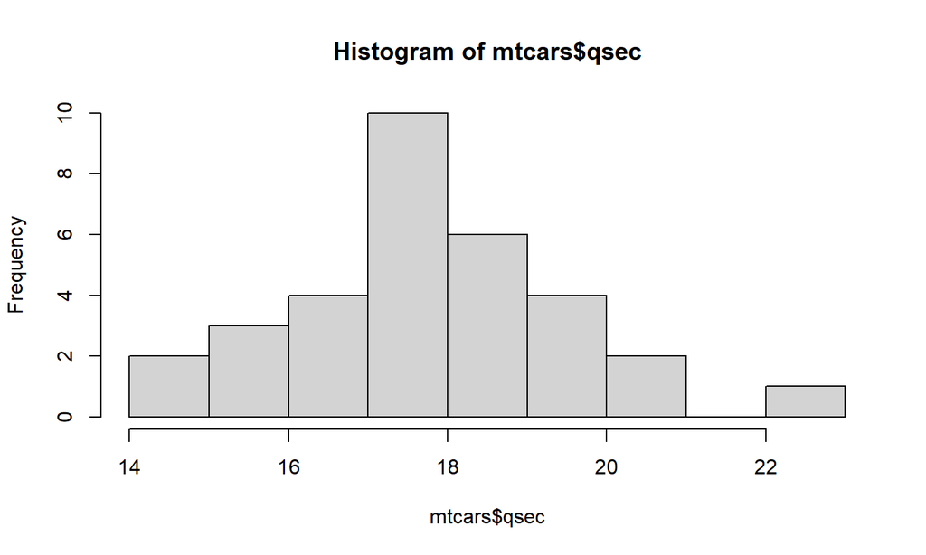

```r
hist(mtcars$qsec) # histogram for 1/4 mile time
```

## Basic functions - Visualising data (cont.)

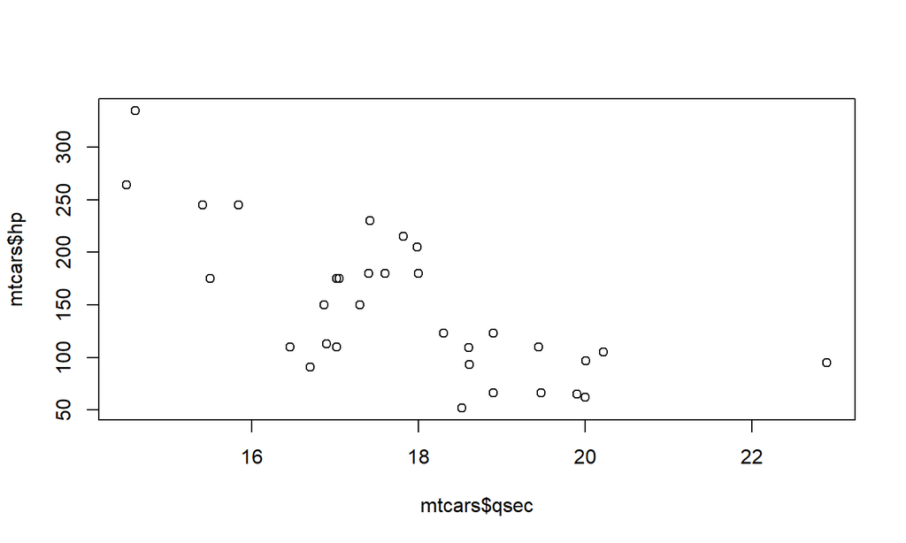

```r
plot(mtcars$qsec, mtcars$hp) # scatter plot for hp and qsec
```

## Basic functions - Summarize variables

```r
mean(mtcars$hp)
```

```
## [1] 146.6875
```

```r
sd(mtcars$hp)
```

```
## [1] 68.56287
```

```r
cor(mtcars[,c(4,6,7)])
```

```
##              hp         wt       qsec
## hp    1.0000000  0.6587479 -0.7082234
## wt    0.6587479  1.0000000 -0.1747159
## qsec -0.7082234 -0.1747159  1.0000000
```

## R formulas

- Special class of object
- Used to specify statistical models

```r
form <- y ~ x
class(form)
```

```
## [1] "formula"
```

The tilde operator (**~**) tells R that the code should be treated as a formula  
- Dependent (response) variable at tilde’s left-hand side  
- Predictors at tilde’s right-hand side  
- Different predictors can be included using the plus sign (**+**)

*other elements can be used to modify the formula*

## R formulas (cont.)

- y as a function of x: y ~ x
- y as a function of x and z: y ~ x + z
- y as a function of x, z and the interactions xz: y ~ x*z

```r
names(mtcars)
```

```
##  [1] "mpg"  "cyl"  "disp" "hp"   "drat" "wt"   "qsec" "vs"   "am"   "gear"
## [11] "carb"
```

```r
model1 <- lm(qsec ~ hp, data = mtcars) # linear regression model
```

## R formulas (cont.)

```r
summary(model1)
```

```
##
## Call:
## lm(formula = qsec ~ hp, data = mtcars)
##
## Residuals:
##     Min      1Q  Median      3Q     Max
## -2.1766 -0.6975  0.0348  0.6520  4.0972
##
## Coefficients:
##              Estimate Std. Error t value Pr(>|t|)
## (Intercept) 20.556354   0.542424  37.897  < 2e-16 ***
## hp          -0.018458   0.003359  -5.495 5.77e-06 ***
## ---
## Signif. codes:  0 '***' 0.001 '**' 0.01 '*' 0.05 '.' 0.1 ' ' 1
##
## Residual standard error: 1.282 on 30 degrees of freedom
## Multiple R-squared:  0.5016, Adjusted R-squared:  0.485
## F-statistic: 30.19 on 1 and 30 DF,  p-value: 5.766e-06
```

## R formulas (cont.)

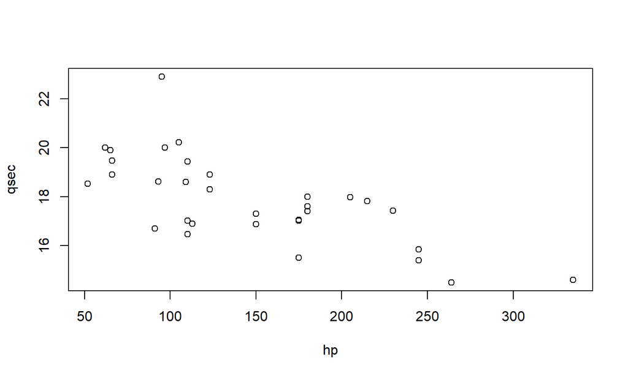

```r
plot(qsec ~ hp, data = mtcars)
```